# Main analysis with imputed missung values

Author

R. Gaizauskaite

### Libraries

```r
library(tidyverse)
library(rstatix)
library(gtsummary)
library(lmtest)
library(ggpubr)
library(car)
library(MASS)
library(nortest)
```

## 1. Main analysis

### 1. 1 Demographic table

```r
Demographic_data <- CST_full_parameters |> dplyr::select(Age:Tes,-Sex, -anxiety)

demographic_summary_1 <- Demographic_data |>
  tbl_summary(
    by = Group,
    missing = "no",
    statistic = list(
      all_continuous() ~ "{mean} ({sd})"
    )
  ) |>
  add_p(
    test = all_continuous() ~ "aov",
    pvalue_fun = function(x) style_pvalue(x, digits = 2)
  )

demographic_summary_1
```

| **Characteristic** | **Males**, N = 35<sup>1</sup> | **NCF**, N = 34<sup>1</sup> | **NCL**, N = 27<sup>1</sup> | **OC**, N = 27<sup>1</sup> | **IUD**, N = 31<sup>1</sup> | **p-value**<sup>2</sup> |
| --- | --- | --- | --- | --- | --- | --- |
| Age | 26.5 (4.1) | 27.2 (5.2) | 26.4 (4.3) | 24.1 (3.6) | 27.5 (4.3) | 0.042 |
| STEM |  |  |  |  |  | 0.004 |
| 0 | 11 (31%) | 26 (76%) | 17 (63%) | 14 (52%) | 19 (61%) |  |
| 1 | 24 (69%) | 8 (24%) | 10 (37%) | 13 (48%) | 12 (39%) |  |
| PANAS_PA | 35.5 (4.8) | 38.3 (5.7) | 35.7 (6.3) | 34.8 (5.7) | 36.8 (6.2) | 0.13 |
| PANAS_NA | 23 (7) | 25 (7) | 26 (9) | 24 (7) | 26 (6) | 0.36 |
| EA1 | 2.59 (1.97) | 3.67 (2.35) | 3.14 (2.40) | 3.26 (2.51) | 3.59 (2.34) | 0.32 |
| EA2 | 3.79 (2.44) | 5.02 (2.62) | 4.95 (2.55) | 4.57 (2.66) | 4.83 (2.81) | 0.30 |
| Tiredness_1 | 3.11 (2.16) | 2.80 (2.29) | 3.16 (2.44) | 2.92 (2.34) | 2.94 (2.25) | 0.97 |
| Tiredness_2 | 5.32 (2.33) | 5.10 (2.23) | 6.26 (2.05) | 5.52 (1.79) | 5.57 (2.48) | 0.34 |
| Femininity | 4.37 (0.46) | 5.05 (0.53) | 5.10 (0.41) | 4.81 (0.48) | 4.88 (0.54) | <0.001 |
| Masculinity | 4.79 (0.66) | 4.31 (0.64) | 4.30 (0.62) | 4.25 (0.75) | 4.10 (0.80) | 0.001 |
| P4 | NA (NA) | 64 (34) | 265 (114) | 105 (62) | 100 (85) | <0.001 |
| E2 | NA (NA) | 1.36 (0.50) | 1.62 (0.48) | 1.26 (0.82) | 1.48 (0.63) | 0.15 |
| Tes | 234 (65) | 73 (24) | 77 (22) | 57 (17) | 84 (35) | <0.001 |

<sup>1</sup> Mean (SD); n (%)  
<sup>2</sup> One-way ANOVA; Pearson’s Chi-squared test

### 1.2. Running ANOVA

#### Assumption test:

**Homogeneity of regression slope**

```r
CST_full_parameters |>  anova_test(accu ~ Group*Age*STEM)
```

```
ANOVA Table (type II tests)

          Effect DFn DFd     F     p p<.05   ges
1          Group   4 134 3.785 0.006     * 0.102
2            Age   1 134 0.314 0.576       0.002
3           STEM   1 134 2.614 0.108       0.019
4      Group:Age   4 134 1.738 0.145       0.049
5     Group:STEM   4 134 0.112 0.978       0.003
6       Age:STEM   1 134 0.668 0.415       0.005
7 Group:Age:STEM   4 134 0.564 0.689       0.017
```

No interaction with age, meaning the homogeneity in slopes all group conditions

**Normality of assumption**

```r
CST_full_parameters |>
  group_by(Group) |>
  shapiro_test(accu)
```

```
# A tibble: 5 × 4
  Group variable statistic        p
  <fct> <chr>        <dbl>    <dbl>
1 Males accu         0.848 0.000205
2 NCF   accu         0.965 0.330
3 NCL   accu         0.966 0.489
4 OC    accu         0.948 0.197
5 IUD   accu         0.944 0.105
```

Violated just in males group, probably due to sealing effect. In men group n > 30, still can use parametric statistic (central limit theorem).

**Homoscedasticity test**

```r
model <- lm(accu ~ Group + STEM, data = CST_full_parameters)
bptest(model)
```

```
    studentized Breusch-Pagan test

data:  model
BP = 2.2414, df = 5, p-value = 0.8148
```

Homoscedasticity assumption is not violated

#### ANOVA

```r
aov_1 <- CST_full_parameters |>
  anova_test(accu ~ Age + STEM + Group)
get_anova_table(aov_1)
```

```
ANOVA Table (type II tests)

  Effect DFn DFd     F     p p<.05      ges
1    Age   1 147 0.107 0.744       0.000725
2   STEM   1 147 2.684 0.104       0.018000
3  Group   4 147 3.981 0.004     * 0.098000
```

#### Pairwise comparison:

```r
pwc <- CST_full_parameters |>
  emmeans_test(
    accu ~ Group, covariate = Age,
    p.adjust.method = "bonferroni"
    )
pwc
```

```
# A tibble: 10 × 9
   term      .y.   group1 group2    df statistic         p    p.adj p.adj.signif
 * <chr>     <chr> <chr>  <chr>  <dbl>     <dbl>     <dbl>    <dbl> <chr>
 1 Age*Group accu  Males  NCF      148     3.37  0.000960  0.00960  **
 2 Age*Group accu  Males  NCL      148     4.05  0.0000838 0.000838 ***
 3 Age*Group accu  Males  OC       148     2.95  0.00375   0.0375   *
 4 Age*Group accu  Males  IUD      148     1.74  0.0840    0.840    ns
 5 Age*Group accu  NCF    NCL      148     0.866 0.388     1        ns
 6 Age*Group accu  NCF    OC       148    -0.179 0.858     1        ns
 7 Age*Group accu  NCF    IUD      148    -1.54  0.126     1        ns
 8 Age*Group accu  NCL    OC       148    -0.984 0.327     1        ns
 9 Age*Group accu  NCL    IUD      148    -2.29  0.0232    0.232    ns
10 Age*Group accu  OC     IUD      148    -1.24  0.218     1        ns
```

#### Graphic

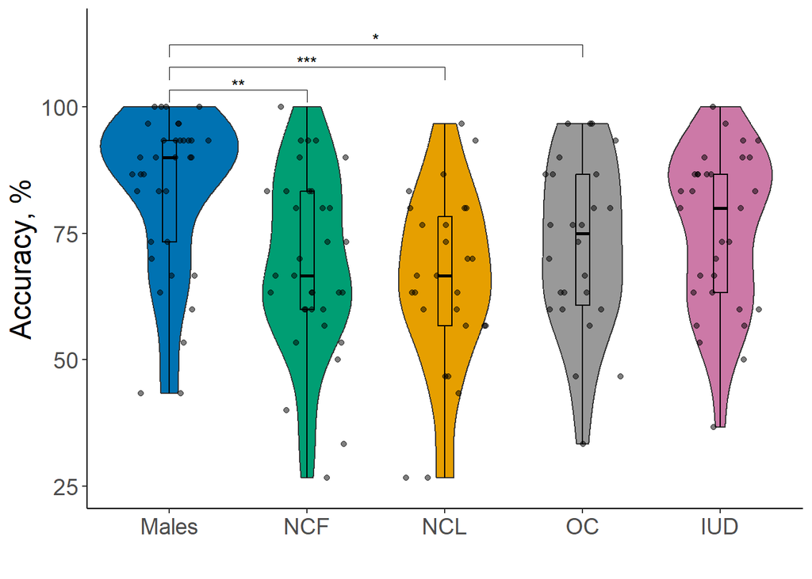

```r
pwc <- pwc |> add_xy_position(x = "Group")
pwc$y.position <- pwc$y.position+3
Anova_result <- ggplot(CST_full_parameters, aes(Group, accu)) +
  geom_violin(aes(fill = Group), width = 1) +
  geom_boxplot(aes(fill = Group), width = 0.1, color = "black", alpha = 0.2) +
  geom_jitter(width = 0.3, height = 0, alpha = 0.5, color = "black") +
  labs(x = " ", y = "Accuracy, %") +
  scale_fill_manual(values = c("#0072B2", "#009E73", "#E69F00", "#999999", "#CC79A7")) +
  scale_y_continuous(limits = c(25, 115)) +  # Set y-axis limits
  theme_classic() +
  theme(axis.text = element_text(size = 14), legend.position = "none") +
  theme(axis.title = element_text(size = 18)) +
  stat_pvalue_manual(pwc, step.increase = 0.05, hide.ns = TRUE)


Anova_result
```

### 1.3. Linear regression model

### 1.3.1 Women

#### Running first LM model with all the variables

```r
women_lm_model <- lm(accu~ OC + IUD + NCL + Age + STEM + PANAS_PA + PANAS_NA + EA1 + EA2 + Tiredness_1 + Tiredness_2 + Femininity + Masculinity + P4 + E2 +Tes, data = women_data)
```

```r
summary(women_lm_model)
```

```
Call:
lm(formula = accu ~ OC + IUD + NCL + Age + STEM + PANAS_PA +
    PANAS_NA + EA1 + EA2 + Tiredness_1 + Tiredness_2 + Femininity +
    Masculinity + P4 + E2 + Tes, data = women_data)

Residuals:
    Min      1Q  Median      3Q     Max
-44.997  -9.506   1.682  11.476  29.603

Coefficients:
              Estimate Std. Error t value Pr(>|t|)
(Intercept) 108.237970  23.602103   4.586 1.29e-05 ***
OC1          -3.510984   4.805107  -0.731 0.466651
IUD1          5.220034   4.408778   1.184 0.239161
NCL1         -6.692658   6.177699  -1.083 0.281204
Age          -0.307085   0.413176  -0.743 0.459051
STEM1         3.185125   3.733293   0.853 0.395565
PANAS_PA     -0.096009   0.335676  -0.286 0.775446
PANAS_NA     -0.166943   0.251376  -0.664 0.508113
EA1           0.120589   0.768212   0.157 0.875576
EA2          -2.346106   0.666716  -3.519 0.000649 ***
Tiredness_1  -0.214127   0.742727  -0.288 0.773703
Tiredness_2  -0.001596   0.838480  -0.002 0.998485
Femininity   -5.096695   3.641789  -1.400 0.164696
Masculinity   3.259339   2.519698   1.294 0.198745
P4            0.012190   0.022134   0.551 0.583023
E2            0.471783   2.922385   0.161 0.872068
Tes          -0.018540   0.069457  -0.267 0.790060
---
Signif. codes:  0 '***' 0.001 '**' 0.01 '*' 0.05 '.' 0.1 ' ' 1

Residual standard error: 16.65 on 102 degrees of freedom
Multiple R-squared:  0.231, Adjusted R-squared:  0.1104
F-statistic: 1.915 on 16 and 102 DF,  p-value: 0.027
```

#### Multicolinearity check up

```r
vif(women_lm_model)
```

```
         OC         IUD         NCL         Age        STEM    PANAS_PA
   1.737695    1.606559    2.872242    1.531774    1.380009    1.767833
   PANAS_NA         EA1         EA2 Tiredness_1 Tiredness_2  Femininity
   1.285211    1.418526    1.313194    1.240607    1.423034    1.450158
Masculinity          P4          E2         Tes
   1.333828    2.438722    1.401705    1.513900
```

All VIF score < 3, no multicolinearity

#### AIC procedure

```r
stepAIC(women_lm_model, direction = "backward")
```

```
Start:  AIC=685.07
accu ~ OC + IUD + NCL + Age + STEM + PANAS_PA + PANAS_NA + EA1 +
    EA2 + Tiredness_1 + Tiredness_2 + Femininity + Masculinity +
    P4 + E2 + Tes

              Df Sum of Sq   RSS    AIC
- Tiredness_2  1       0.0 28290 683.07
- EA1          1       6.8 28297 683.10
- E2           1       7.2 28298 683.10
- Tes          1      19.8 28310 683.15
- PANAS_PA     1      22.7 28313 683.16
- Tiredness_1  1      23.1 28313 683.16
- P4           1      84.1 28374 683.42
- PANAS_NA     1     122.3 28413 683.58
- OC           1     148.1 28438 683.69
- Age          1     153.2 28443 683.71
- STEM         1     201.9 28492 683.91
- NCL          1     325.5 28616 684.43
- IUD          1     388.8 28679 684.69
- Masculinity  1     464.1 28754 685.00
<none>                     28290 685.07
- Femininity   1     543.2 28834 685.33
- EA2          1    3434.4 31725 696.70

Step:  AIC=683.07
accu ~ OC + IUD + NCL + Age + STEM + PANAS_PA + PANAS_NA + EA1 +
    EA2 + Tiredness_1 + Femininity + Masculinity + P4 + E2 +
    Tes

              Df Sum of Sq   RSS    AIC
- EA1          1       6.9 28297 681.10
- E2           1       7.2 28298 681.10
- Tes          1      19.8 28310 681.15
- PANAS_PA     1      22.7 28313 681.16
- Tiredness_1  1      25.7 28316 681.17
- P4           1      85.8 28376 681.43
- PANAS_NA     1     129.7 28420 681.61
- OC           1     151.4 28442 681.70
- Age          1     156.1 28446 681.72
- STEM         1     207.3 28498 681.94
```

[output cut: 163 more lines]

```
<none>                     29072 666.31
- Masculinity  1     601.8 29674 666.75
- Femininity   1     921.3 29994 668.02
- IUD          1    1071.8 30144 668.62
- EA2          1    4537.2 33610 681.57

Step:  AIC=666.25
accu ~ IUD + EA2 + Femininity + Masculinity

              Df Sum of Sq   RSS    AIC
<none>                     29551 666.25
- Masculinity  1     927.0 30478 667.93
- Femininity   1    1093.3 30644 668.58
- IUD          1    1146.9 30697 668.78
- EA2          1    4475.8 34026 681.04
```

```
Call:
lm(formula = accu ~ IUD + EA2 + Femininity + Masculinity, data = women_data)

Coefficients:
(Intercept)         IUD1          EA2   Femininity  Masculinity
     93.032        7.145       -2.345       -6.138        4.096
```

As model suggest IUD group to stay, i would do little bit differently and IUD group leave as reference group to account for all hormonal status groups.

#### Final model

```r
women_final <- lm(accu ~ OC + NCF + NCL + EA2 + Femininity + Masculinity, data  = women_data)
```

```r
summary(women_final)
```

```
Call:
lm(formula = accu ~ OC + NCF + NCL + EA2 + Femininity + Masculinity,
    data = women_data)

Residuals:
    Min      1Q  Median      3Q     Max
-46.669  -9.957   1.578  11.715  29.121

Coefficients:
            Estimate Std. Error t value Pr(>|t|)
(Intercept)  99.2104    16.3707   6.060 1.87e-08 ***
OC1          -6.5781     4.2847  -1.535   0.1275
NCF1         -5.8697     4.0722  -1.441   0.1523
NCL1         -9.3827     4.3232  -2.170   0.0321 *
EA2          -2.3425     0.5685  -4.121 7.27e-05 ***
Femininity   -5.9213     3.0712  -1.928   0.0564 .
Masculinity   4.0699     2.1780   1.869   0.0643 .
---
Signif. codes:  0 '***' 0.001 '**' 0.01 '*' 0.05 '.' 0.1 ' ' 1

Residual standard error: 16.19 on 112 degrees of freedom
Multiple R-squared:  0.2022,    Adjusted R-squared:  0.1594
F-statistic:  4.73 on 6 and 112 DF,  p-value: 0.0002494
```

#### Assumption testing

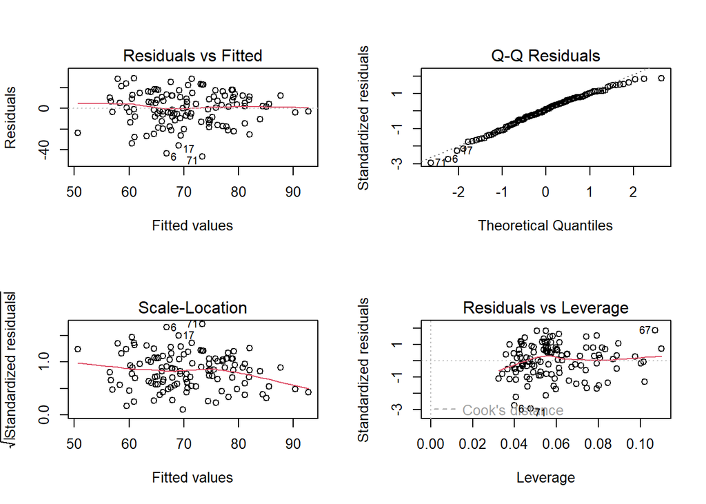

**Homoscedasticity test**

```r
bptest(women_final)
```

```
    studentized Breusch-Pagan test

data:  women_final
BP = 3.4794, df = 6, p-value = 0.7467
```

Homoscedacity assumption is not violated, p > 0.05

**Independence of Errors test:**

```r
durbinWatsonTest(women_final)
```

```
 lag Autocorrelation D-W Statistic p-value
   1     -0.03253187       2.06171   0.904
 Alternative hypothesis: rho != 0
```

**Conclusion:** The model show good fit.

#### Polinomynal regression analysis for testosterone

```r
quadratic_model_women <- lm(accu  ~ poly(Tes, 2, raw = TRUE), data = women_data)
summary(quadratic_model_women)
```

```
Call:
lm(formula = accu ~ poly(Tes, 2, raw = TRUE), data = women_data)

Residuals:
    Min      1Q  Median      3Q     Max
-46.236  -9.973   0.230  13.541  30.455

Coefficients:
                           Estimate Std. Error t value Pr(>|t|)
(Intercept)               76.879569   9.057548   8.488 7.99e-14 ***
poly(Tes, 2, raw = TRUE)1 -0.200221   0.204474  -0.979    0.330
poly(Tes, 2, raw = TRUE)2  0.001346   0.001077   1.249    0.214
---
Signif. codes:  0 '***' 0.001 '**' 0.01 '*' 0.05 '.' 0.1 ' ' 1

Residual standard error: 17.65 on 116 degrees of freedom
Multiple R-squared:  0.01781,   Adjusted R-squared:  0.0008787
F-statistic: 1.052 on 2 and 116 DF,  p-value: 0.3526
```

No quadratic effect of testosterone.

### 1.3.2. Men

**Tidying the table**

#### Running first LM model with all the variables

```r
men_lm_model <- lm(accu~ Age + STEM + PANAS_PA + PANAS_NA + EA1 + EA2 + Tiredness_1 + Tiredness_2 + Femininity + Masculinity +Tes, data = men_data)
```

```r
summary(men_lm_model)
```

```
Call:
lm(formula = accu ~ Age + STEM + PANAS_PA + PANAS_NA + EA1 +
    EA2 + Tiredness_1 + Tiredness_2 + Femininity + Masculinity +
    Tes, data = men_data)

Residuals:
    Min      1Q  Median      3Q     Max
-36.430  -8.505   3.383   8.755  17.826

Coefficients:
             Estimate Std. Error t value Pr(>|t|)
(Intercept) 100.04950   55.88861   1.790   0.0866 .
Age          -0.13650    0.78269  -0.174   0.8631
STEM1         4.31799    6.58448   0.656   0.5185
PANAS_PA     -0.65658    0.93059  -0.706   0.4876
PANAS_NA     -0.13074    0.50313  -0.260   0.7973
EA1           3.90035    1.74041   2.241   0.0350 *
EA2          -1.42718    1.43245  -0.996   0.3295
Tiredness_1  -2.82579    1.74290  -1.621   0.1186
Tiredness_2   0.68772    1.56317   0.440   0.6641
Femininity   -0.96053    8.34619  -0.115   0.9094
Masculinity   6.60534    5.60708   1.178   0.2508
Tes          -0.07162    0.05329  -1.344   0.1921
---
Signif. codes:  0 '***' 0.001 '**' 0.01 '*' 0.05 '.' 0.1 ' ' 1

Residual standard error: 15.75 on 23 degrees of freedom
Multiple R-squared:  0.3348,    Adjusted R-squared:  0.01662
F-statistic: 1.052 on 11 and 23 DF,  p-value: 0.437
```

#### AIC procedure

```r
stepAIC(men_lm_model, direction = "backward")
```

```
Start:  AIC=202.29
accu ~ Age + STEM + PANAS_PA + PANAS_NA + EA1 + EA2 + Tiredness_1 +
    Tiredness_2 + Femininity + Masculinity + Tes

              Df Sum of Sq    RSS    AIC
- Femininity   1      3.29 5709.5 200.31
- Age          1      7.55 5713.7 200.34
- PANAS_NA     1     16.75 5722.9 200.39
- Tiredness_2  1     48.02 5754.2 200.58
- STEM         1    106.69 5812.9 200.94
- PANAS_PA     1    123.50 5829.7 201.04
- EA2          1    246.27 5952.4 201.77
<none>                     5706.2 202.29
- Masculinity  1    344.30 6050.5 202.34
- Tes          1    448.05 6154.2 202.93
- Tiredness_1  1    652.15 6358.3 204.08
- EA1          1   1246.01 6952.2 207.20

Step:  AIC=200.31
accu ~ Age + STEM + PANAS_PA + PANAS_NA + EA1 + EA2 + Tiredness_1 +
    Tiredness_2 + Masculinity + Tes

              Df Sum of Sq    RSS    AIC
- Age          1      9.14 5718.6 198.37
- PANAS_NA     1     18.87 5728.3 198.42
- Tiredness_2  1     45.00 5754.5 198.58
- STEM         1    141.44 5850.9 199.16
- PANAS_PA     1    162.72 5872.2 199.29
- EA2          1    243.07 5952.5 199.77
<none>                     5709.5 200.31
- Masculinity  1    341.07 6050.5 200.34
- Tes          1    464.39 6173.8 201.05
- Tiredness_1  1    659.21 6368.7 202.13
- EA1          1   1468.73 7178.2 206.32

Step:  AIC=198.36
accu ~ STEM + PANAS_PA + PANAS_NA + EA1 + EA2 + Tiredness_1 +
    Tiredness_2 + Masculinity + Tes

              Df Sum of Sq    RSS    AIC
```

[output cut: 81 more lines]

```

Step:  AIC=190.94
accu ~ EA1 + Tes

       Df Sum of Sq    RSS    AIC
- Tes   1    337.12 7238.3 190.61
<none>              6901.2 190.94
- EA1   1   1430.75 8332.0 195.54

Step:  AIC=190.61
accu ~ EA1

       Df Sum of Sq    RSS    AIC
<none>              7238.3 190.61
- EA1   1    1339.4 8577.8 194.56
```

```
Call:
lm(formula = accu ~ EA1, data = men_data)

Coefficients:
(Intercept)          EA1
     75.104        3.179
```

#### Final model

```r
men_final <- lm(accu ~ EA1, data = men_data)
```

```r
summary(men_final)
```

```
Call:
lm(formula = accu ~ EA1, data = men_data)

Residuals:
    Min      1Q  Median      3Q     Max
-36.222  -7.493   2.507  10.041  21.717

Coefficients:
            Estimate Std. Error t value Pr(>|t|)
(Intercept)   75.104      4.166  18.027   <2e-16 ***
EA1            3.179      1.286   2.471   0.0188 *
---
Signif. codes:  0 '***' 0.001 '**' 0.01 '*' 0.05 '.' 0.1 ' ' 1

Residual standard error: 14.81 on 33 degrees of freedom
Multiple R-squared:  0.1562,    Adjusted R-squared:  0.1306
F-statistic: 6.107 on 1 and 33 DF,  p-value: 0.0188
```

#### Assumptions testing

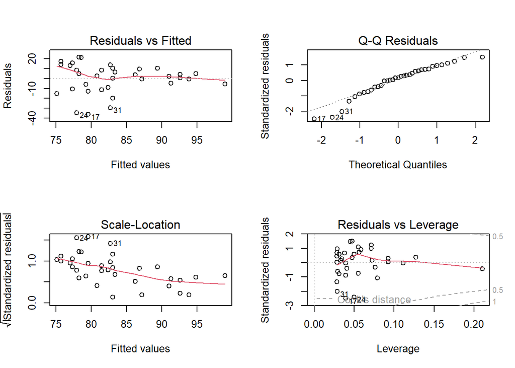

**Normality of residuals**

```r
ad.test(model.metrics.men$.resid)
```

```
    Anderson-Darling normality test

data:  model.metrics.men$.resid
A = 0.65699, p-value = 0.07919
```

IN QQ plot we can see that there is three outliers, otherwise the plot looks normal. At larger sample sizes the Shapiro-Wilk test becomes very sensitive even to a minor deviation from normality. Anderson-Darling normality test p > 0.05, therefore I assume normal distribution.

**Homoscedasticity test**

```r
bptest(men_final)
```

```
    studentized Breusch-Pagan test

data:  men_final
BP = 4.8826, df = 1, p-value = 0.02713
```

**Independence of Errors test:**

```r
durbinWatsonTest(men_final)
```

```
 lag Autocorrelation D-W Statistic p-value
   1      -0.3025498      2.593666   0.058
 Alternative hypothesis: rho != 0
```

**Conclusion:** Some assumptions are violated therefore the model should be interpreted with cautious.

#### Polinomynal regression analysis for testosterone

```r
quadratic_model_men <- lm(accu ~ poly(Tes, 2, raw = TRUE), data = men_data)
```

```r
summary(quadratic_model_men)
```

```
Call:
lm(formula = accu ~ poly(Tes, 2, raw = TRUE), data = men_data)

Residuals:
    Min      1Q  Median      3Q     Max
-40.926  -8.982   5.553  11.862  19.408

Coefficients:
                            Estimate Std. Error t value Pr(>|t|)
(Intercept)                1.139e+02  2.780e+01   4.097 0.000267 ***
poly(Tes, 2, raw = TRUE)1 -2.352e-01  2.432e-01  -0.967 0.340844
poly(Tes, 2, raw = TRUE)2  4.150e-04  5.125e-04   0.810 0.424076
---
Signif. codes:  0 '***' 0.001 '**' 0.01 '*' 0.05 '.' 0.1 ' ' 1

Residual standard error: 15.97 on 32 degrees of freedom
Multiple R-squared:  0.04816,   Adjusted R-squared:  -0.01133
F-statistic: 0.8095 on 2 and 32 DF,  p-value: 0.454
```

No quadratic effect of testosterone

### 1.4 Mediation analysis

*Output of mediation analysis is not accessible as PROCESS v4.3 functions available as script, not a R package.*

```r
process (data = CST_full_parameters, y = "accu", x = "Sex", m ="EA2", model = 4, effsize =1, total =1, stand =1, cov = "STEM", boot = 10000 , seed = 654321)
```

Percentage of the difference explained by EA2

```r
Proc_EA <- (0.1400*100)/0.6201
Proc_EA
```

```
[1] 22.577
```